# Data visualization with ggplot2

Data Carpentry

### Learning Objectives

> - Produce scatter plots, boxplots, density plots, and time series plots using `ggplot2`.
> - Set universal and local plot settings.
> - Describe what aesthetics are and how they are used by ggplot().
> - Describe what faceting is and apply faceting to a ggplot().
> - Modify the aesthetics of an existing ggplot() plot (e.g. axis labels, color).
> - Build multivariate and customized plots from data in a data frame.
> - Arrange multiple plots in a grid format using grid.arrange() from gridExtra.
> - Export publication ready graphics using ggsave().

# Warm-up

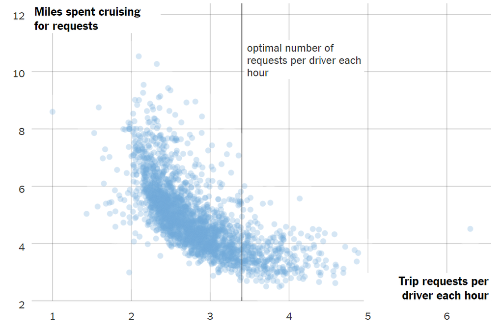

- Describe the qualities of this plot.

# Data Visualization using **`ggplot2`**

**`ggplot2`** is a plotting package that makes it simple to create complex plots from data in a data frame. It provides a more programmatic interface for specifying what variables to plot, how they are displayed, and general visual properties. Therefore, we only need minimal changes if the underlying data change or if we decide to change from a bar plot to a scatter plot. This helps in creating publication quality plots with minimal amounts of adjustments and tweaking.

Packages in `R` are basically sets of additional functions that let you do more stuff. The functions we’ve been using so far, like `str()` or `mean()`, come built into `R`; packages give you access to more of them. Before you use a package for the first time you need to install it on your machine, and then you should import it in every subsequent `R` session when you need it. You should already have installed the **`tidyverse`** package. This is an “umbrella-package” that installs several packages useful for data analysis which work together well such as **`tidyr`**, **`dplyr`**, **`ggplot2`**, **`readr`**, **`forcats`**, etc.

The **`tidyverse`** package tries to address common issues that arise when doing data analysis with some of the functions that come with `R`.

1. The `tidyverse` solves complex problems by combining many simple pieces.

> No matter how complex and polished the individual operations are, it is often the quality of the glue that most directly determines the power of the system. - Hal Abelson
2. The `tidyverse` is written for people to read!

> Computer efficiency is a secondary concern because the bottleneck in most data analysis is thinking time, not computing time. - Hadley Wickham

If we haven’t already done so, we can type `install.packages("tidyverse")` straight into the console. In fact, it’s better to write this in the console than in our script for any package, as there’s no need to re-install packages every time we run the script.

Then, to load the package type:

```r
## load the tidyverse packages
library(tidyverse)
```

To learn more about **`ggplot2`** after the workshop, you may want to check out this [**`ggplot2`** reference website (link)](https://ggplot2.tidyverse.org/reference/) and this [handy cheatsheet on **`ggplot2`** (link)](https://github.com/rstudio/cheatsheets/raw/master/data-visualization-2.1.pdf).

# Data for the Workshop

We have seen in our previous lesson that when building or importing a data frame, the columns that contain characters (i.e., text) are coerced (=converted) into the `factor` data type. We had to set **`stringsAsFactors`** to **`FALSE`** to avoid this hidden argument to convert our data type.

This time we will use the **`readr`** package (from the `tidyverse`) to read in the data and avoid having to set **`stringsAsFactors`** to **`FALSE`**

We’ll read in our data using the `read_csv()` function instead of the `read.csv()` function we used in the *Introduction to `R`* workshop.

```r
surveys <- read_csv("../data/surveys.csv")
```

You will see the message `Parsed with column specification`, followed by each column name and its data type. When you execute `read_csv` on a data file, it looks through the first 1000 rows of each column and guesses the data type for each column as it reads it into `R`. For example, in this dataset, `read_csv` reads `weight` as `col_double` (a numeric data type), and `species` as `col_character`.

```r
## inspect the data
str(surveys)
```

```r
## preview the data
View(surveys)
```

Notice that the class of the data is now `tbl_df`

This is referred to as a “tibble”. Tibbles tweak some of the behaviors of the data frame objects we introduced in the previous workshop. The data structure is very similar to a data frame, so for our purposes the only differences are that:

1. In addition to displaying the data type of each column under its name, it only prints the first few rows of data and only as many columns as fit on one screen.
2. Columns of class `character` are never converted into factors.

## Plotting with **`ggplot2`**

`ggplot2` functions like data in the ‘long’ format, i.e., a column for every dimension, and a row for every observation. There are other data formats, which we will discuss in the *Data Wrangling in `R`* workshop, as well as how to covert from one data format to another. Well-structured data will save you lots of time when making figures with `ggplot2` and when working in `R`!

`ggplot()` graphics are built step by step by adding new elements. Adding layers in this fashion allows for extensive flexibility and customization of plots.

To build a `ggplot()`, we will use the following basic template that can be used for different types of plots:

`ggplot(data = <DATA>, mapping = aes(<VARIABLE MAPPINGS>)) + <GEOM_FUNCTION>()`

Let’s go through this step by step!

1. Use the `ggplot()` function and bind the plot to a specific data frame using the `data` argument

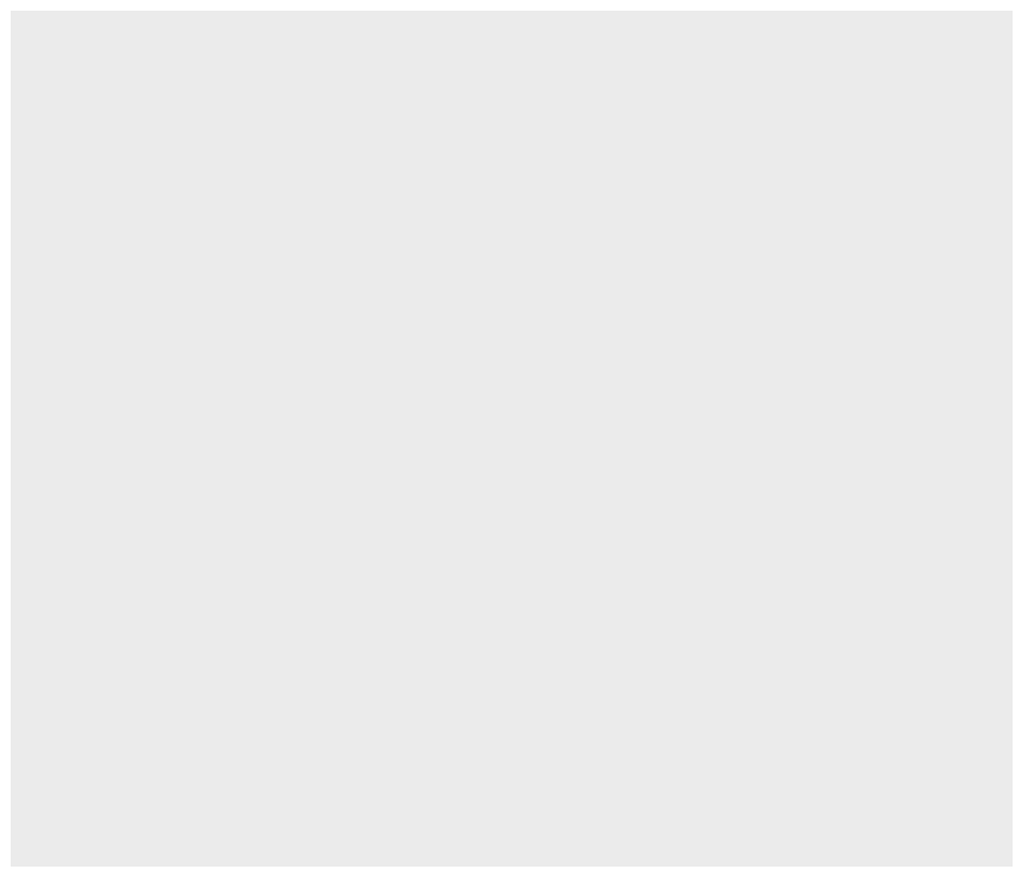

```r
ggplot(data = surveys)
```

```r
## Creates a blank ggplot(), referencing the surveys dataset
```

2. Define a mapping (using the aesthetic (`aes`) function), by selecting the variables to be plotted and specifying how to present them in the graph, e.g. as x/y positions or characteristics such as size, shape, color, etc.

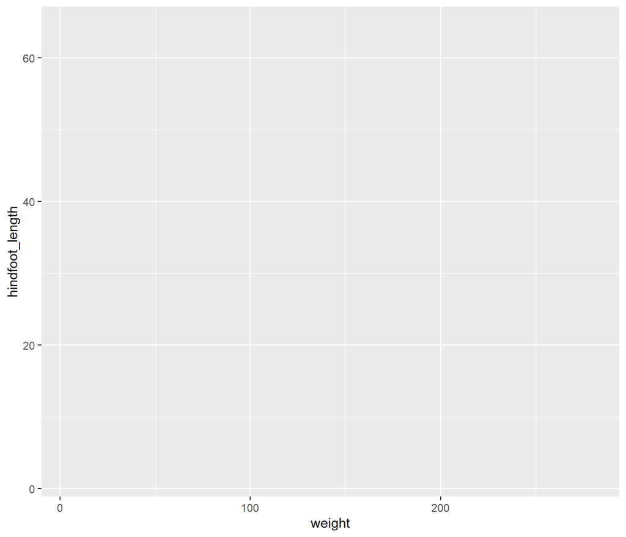

```r
ggplot(data = surveys,
       mapping = aes(x = weight, y = hindfoot_length))
```

```r
## Creates a blank ggplot(), with the variables mapped to the x- and y-axis
## ggplot() knows where the variables live, since you have defined the data to use
```

3. Add ‘geoms’ – graphical representations of the data in the plot (points, lines, bars). **`ggplot2`** offers many different geoms; we will use some common ones today, including:
   - `geom_point()` for scatter plots, dot plots, etc.
   - `geom_boxplot()` for boxplots
   - `geom_bar()` for bar charts
   - `geom_line()` for trend lines, time series, etc.

To add a geom to the plot use the `+` operator. Because we have two continuous variables in the data, let’s use `geom_point()` first:

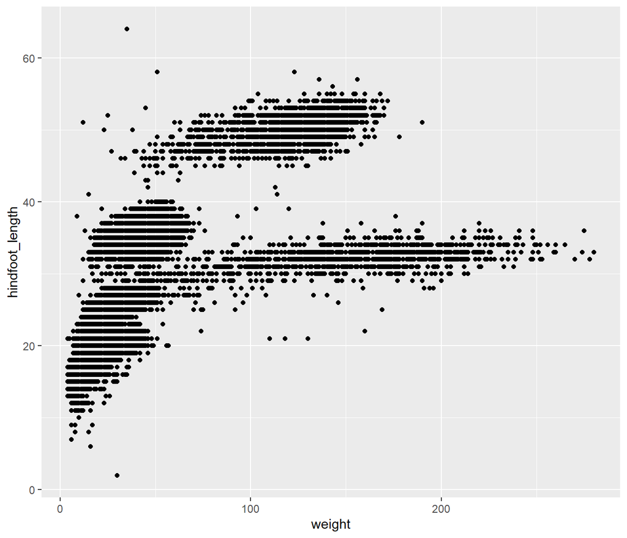

```r
ggplot(data = surveys,
       mapping = aes(x = weight, y = hindfoot_length)) +
  geom_point()
```

```r
 ## Adds a point for each row (observation) in the data
```

You can think of the `+` sign as adding layers to the plot. Each `+` sign must be placed at the end of the line containing the *previous* layer. If, instead, the `+` sign is added at the beginning of the line containing the new layer, **`ggplot2`** will not add the new layer and will return an error message.

```r
# This is the correct syntax for adding layers
surveys_plot +
  geom_point()

# This will not add the new layer and will return an error message
surveys_plot
  + geom_point()
```

## Building Plots Iteratively

Building plots with **`ggplot2`** is typically an iterative process. We start by defining the dataset we’ll use, lay out the axes, and choose a geom:

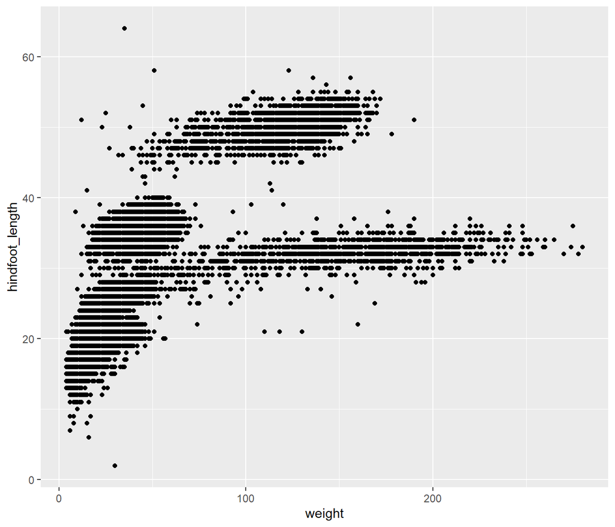

```r
ggplot(data = surveys,
       mapping = aes(x = weight, y = hindfoot_length)) +
    geom_point()
```

Then, we start modifying this plot to extract more information from it. For instance, we can add transparency (`alpha`) to the points, to avoid overplotting:

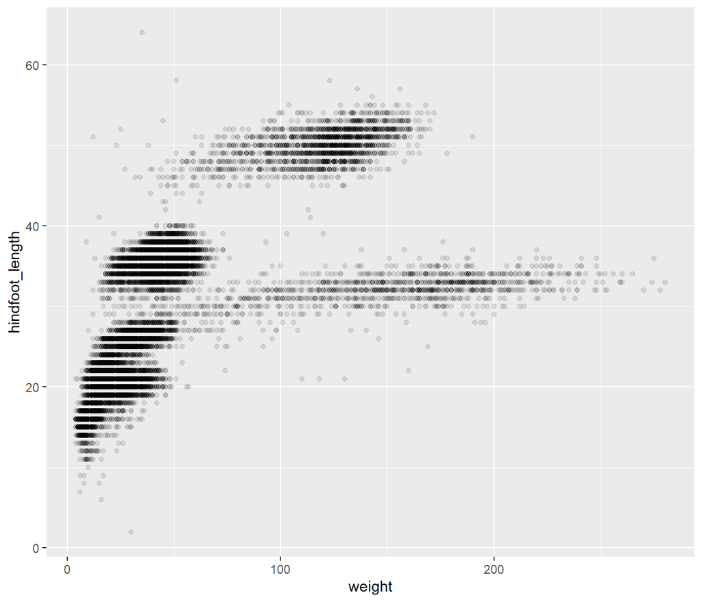

```r
ggplot(data = surveys,
       mapping = aes(x = weight, y = hindfoot_length)) +
    geom_point(alpha = 0.1)
```

```r
    ## alpha reduces the opacity of the points
    ## 0 is fully transparent
    ## 1 is the original opacity
```

We can also add colors for all the points:

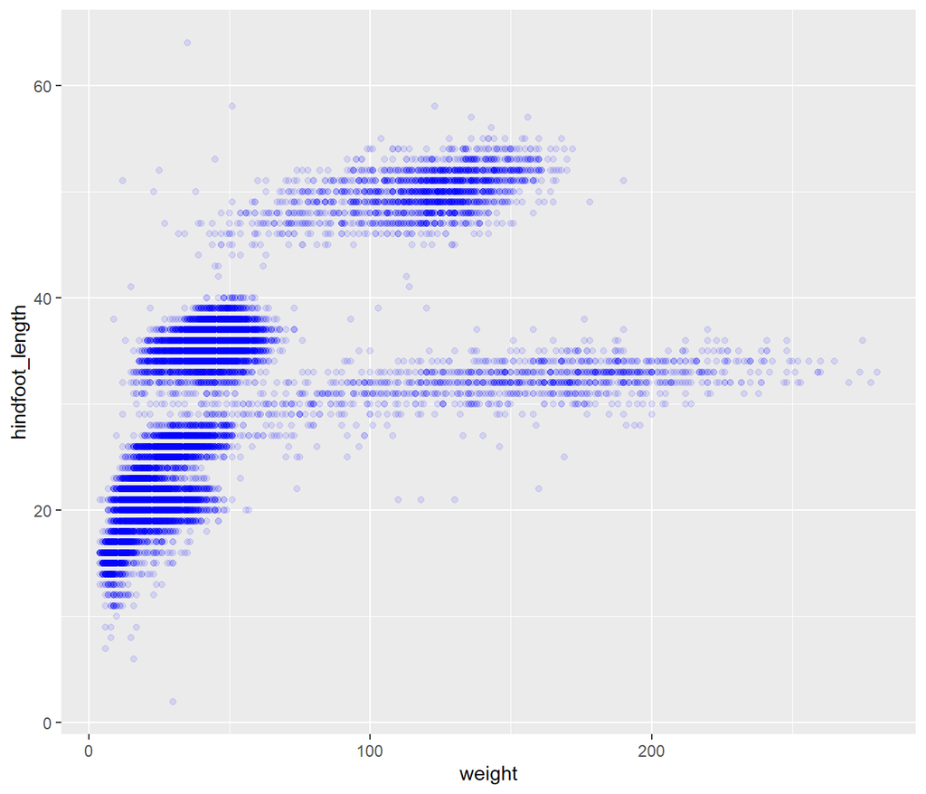

```r
ggplot(data = surveys,
       mapping = aes(x = weight, y = hindfoot_length)) +
    geom_point(alpha = 0.1, color = "blue")
```

### Challenge 1

`geom_point` also accepts aesthetics of size and shape. The size of a point is its width in mm. The shape of a point has five different options for plotting:

- an integer [0, 25] of defined plotting characters – same as base `R`
- the name of the shape in quotations (e.g. “circle open” or “diamond filled”)
- a single character, to use that character as a plotting symbol
- a “.” to draw the smallest point that is visible – typically 1 pixel
- an NA, to draw nothing

Reference for shapes in integers and characters:  
https://ggplot2.tidyverse.org/articles/ggplot2-specs.html

> Modify the previous code chunk to assign one of these aesthetics to the `geom_point` aspect of your plot. What happened?

```r
## Your ggplot code to answer the challenge goes here!
```

## Piping Data In

Because **`ggplot2`** lives in the `tidyverse`, it is expected to work well with other packages in the `tidyverse`. Because of this, the first argument to creating a `ggplot()` is the dataset you wish to be working with. The pipe operator sends the output of one function directly into the next function, which is useful when you need to do many things to the same dataset. Since the dataset we wish to use is the first argument to `ggplot()`, we can use the pipe operator to pipe the data into the `ggplot()` function!

Pipes in `R` look like `%>%` and are made available via the **`magrittr`** package, installed automatically with the **`tidyverse`**. If you use RStudio, you can type the pipe with `Ctrl` + `Shift` + `M` if you have a PC or `Cmd` + `Shift` + `M` if you have a Mac.

This would instead look like this:

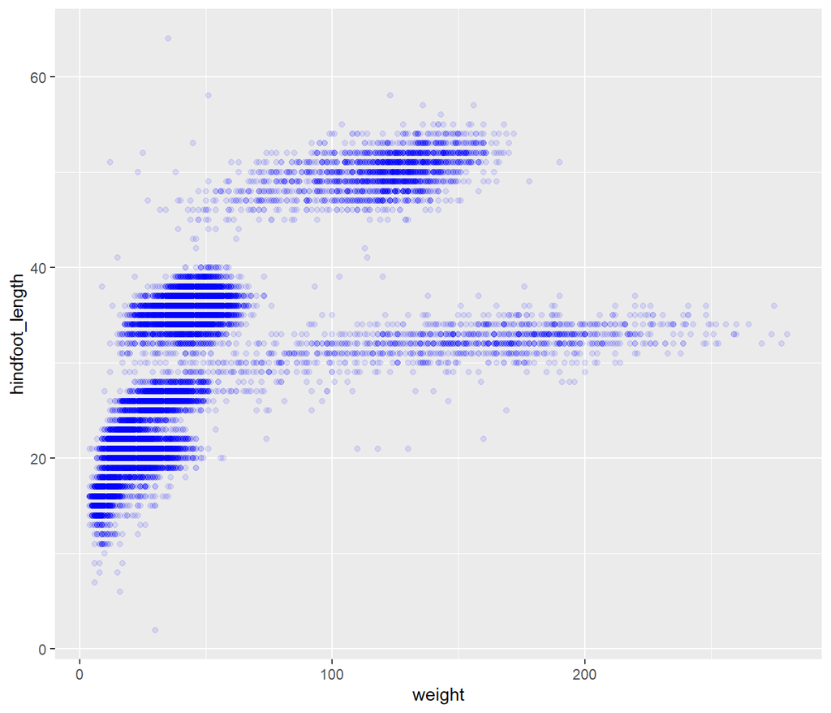

```r
surveys %>%
  ## data to be used in the ggplot
  ggplot(mapping = aes(x = weight, y = hindfoot_length)) +
  ## uses the data piped in as the first arguement to ggplot()
    geom_point(alpha = 0.1, color = "blue")
```

Once we pipe the data in, the first argument becomes the `mapping` of the aesthetics. Technically, we are using the name of this argument, which is why it looks like:

`mapping = aes(<VARIABLES>)`

When we pipe our data in, the first argument then becomes this `mapping` argument.

## Assigning More Variables to Aesthetics

Or to color each species in the plot differently, you could use a vector as an input to the argument **color**. **`ggplot2`** will provide a different color corresponding to different values in the vector. Here is an example where we color with **`species_id`**:

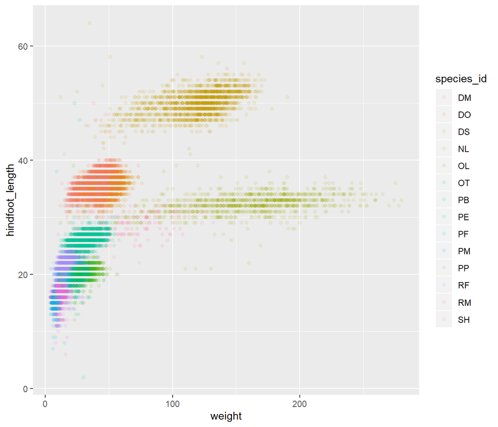

```r
surveys %>%
  ggplot(mapping = aes(x = weight, y = hindfoot_length)) +
    geom_point(alpha = 0.1, aes(color = species_id))
```

**Note:** When specifying an `alpha` for a scatterplot, it automatically uses that **same** `alpha` in the legend. To remedy this you can add:

```
guides(colour = guide_legend(override.aes = list(alpha = 1)))
```

to your plot. This customizes the legend appearance, similar to what we will see in the customization section.

We can also specify the colors directly inside the mapping provided in the `ggplot()` function. This will be seen by **any** geom layers and the mapping will be determined by the x- and y-axis set up in `aes()`.

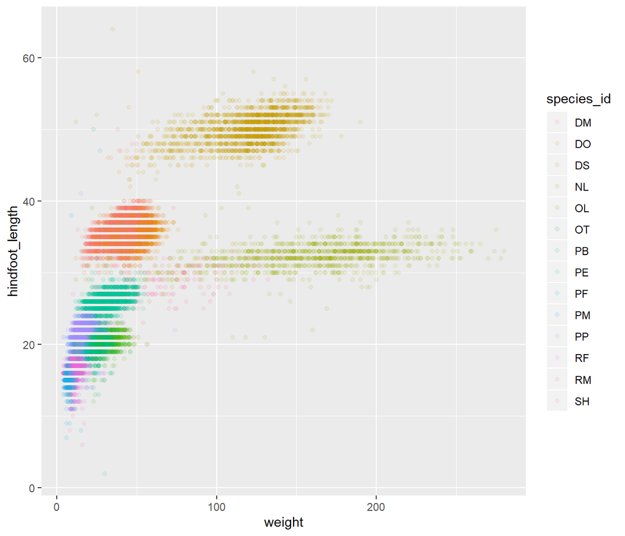

```r
surveys %>%
  ggplot(mapping = aes(x = weight, y = hindfoot_length, color = species_id)) +
    geom_point(alpha = 0.1)
```

Notice that we can change the geom layer and colors will be still determined by **`species_id`**

### Local Aesthetics versus Global Aesthetics

When you define aesthetics in the `ggplot()` function, those mappings hold for **every** aspect of your plot.

For example, if you chose to add a trend line to your plot of weight versus hindfoot length, you would get different lines depending on where you define your color aesthetics.

**Globally**

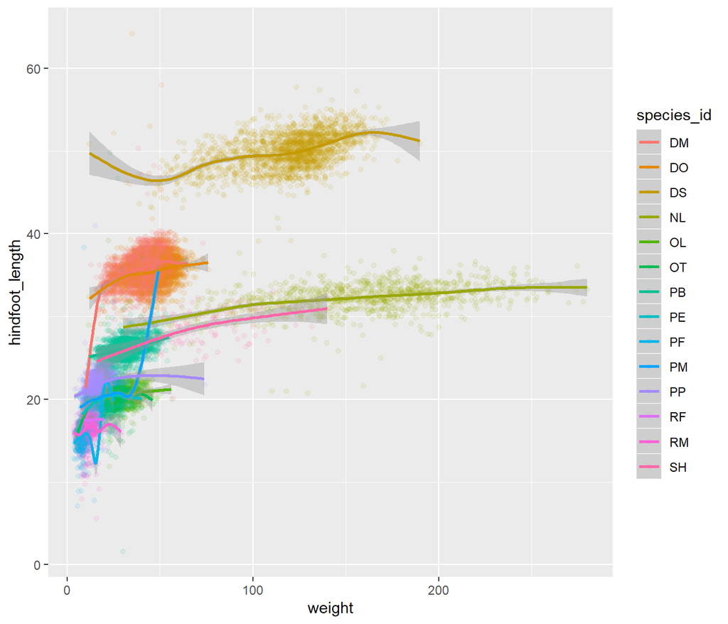

```r
surveys %>%
  ggplot(mapping = aes(x = weight, y = hindfoot_length, color = species_id)) +
  geom_jitter(alpha = 0.1) +
  geom_smooth()
```

```r
  ## trend line for each species_id -- because color is defined globally
```

**Locally**

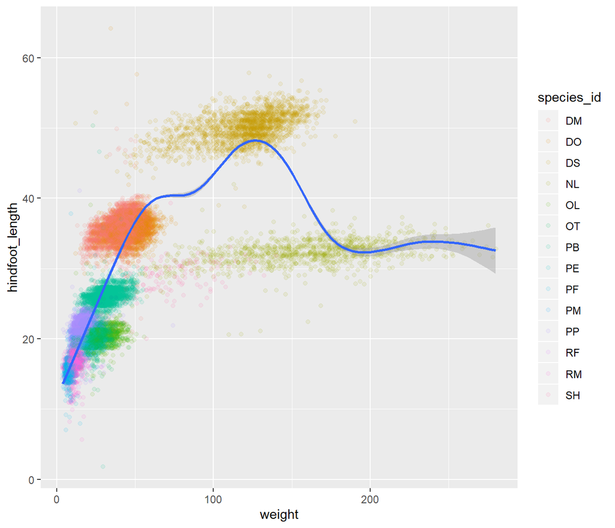

```r
surveys %>%
  ggplot(mapping = aes(x = weight, y = hindfoot_length)) +
  geom_jitter(aes(color = species_id), alpha = 0.1) +
  geom_smooth()
```

```r
  ## one trend line -- no color defined globally
```

### Challenge 2

> Part 1: Inspect the `geom_point` help file to see what other aesthetics are available. Map a new variable from the dataset to another aesthetic in your plot. What happened? Does the aesthetic change if you use a continuous variable versus a categorical/discrete variable?

```r
## Your ggplot() code for the challenge goes here!
```

> Part 2: Use what you just learned to create a scatter plot of `weight` over `plot_id` with data from different plot types being showed in different colors. Is this a good way to show this type of data?

```r
## Your ggplot() code for the challenge goes here!
```

# Boxplots & Violin Plots

We can use boxplots to visualize the distribution of weight within each species:

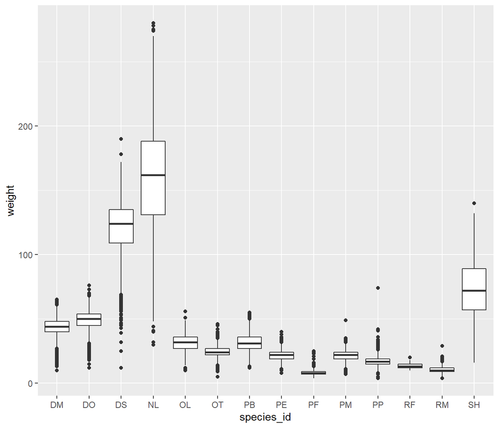

```r
surveys %>%
  ggplot(mapping = aes(x = species_id, y = weight)) +
    geom_boxplot()
```

By adding points to boxplot, we can have a better idea of the number of measurements and their distribution:

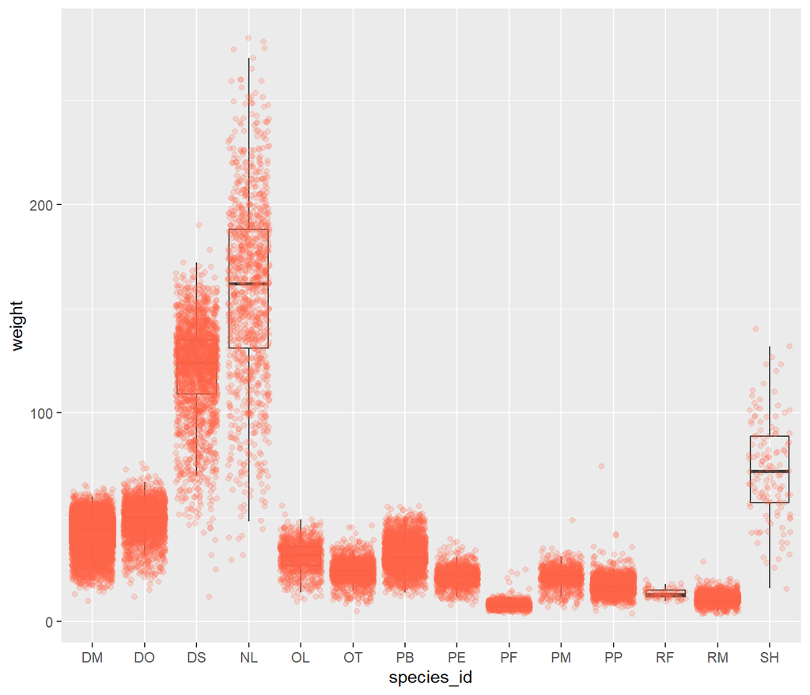

```r
surveys %>%
  ggplot(mapping = aes(x = species_id, y = weight)) +
    geom_boxplot(alpha = 0) +
    ## alpha = 0 eliminates the black (outlier) points, so they're not plotted twice
    geom_jitter(alpha = 0.2, color = "tomato")
```

```r
    ## alpha = 0.2 decreases the opacity of the points, to not be too busy
```

> Notice how the boxplot layer is behind the jitter layer? What would you change in the code to put the boxplot in front of the points?

### Challenge 3

> Part 1: Boxplots are useful summaries, but hide the *shape* of the distribution. For example, if the distribution is bimodal, we would not see it in a boxplot. A superior density plot is the violin plot, where the shape (of the density of points) is drawn.

> Replace the box plot with a violin plot. For help see `geom_violin()`.

```r
##  Start with the boxplot we created:
ggplot(data = surveys, mapping = aes(x = species_id, y = weight)) +
  geom_boxplot(alpha = 0) +
  geom_jitter(alpha = 0.3, color = "tomato")

##  1. Replace the boxplot with a violin plot. For help, see geom_violin().
```

> Part 2: So far, we’ve looked at the distribution of weight within species. Let’s try making a new plot to explore the distribution of another variable within each species.

> Create a boxplot for `hindfoot_length`. Overlay the boxplot layer on a jitter layer to show actual measurements.

```r
##  First: create boxplot for hindfoot_length` overlaid on a jitter layer.
```

> Now, add color to the data points on your boxplot according to the plot from which the sample was taken (`plot_id`).

> *Hint:* Check the class for `plot_id`. If `plot_id` was a character instead, how would the graph be different?

```r
## Next: add color to the data points on your boxplot according to the
## plot from which the sample was taken (plot_id).


## Hint: Check the class for plot_id`. If plot_id was a character instead,
## how would the graph be different?
```

# Plotting Single Variables – Quantitative & Categorical

## Distribution Plots

If we wish to visualize the distribution of a single quantitative variable, our plot changes a bit. Unfortunately, the `geom_violin()` function only accepts groups, so we cannot make a violin plot with no groups. Darn it!

But, a violin is simply a density plot that’s been reflected across the y-axis. So, we could likely suffice with a density plot.

To visualize the distribution of rodent weights we could aggregate over all species, years, plots, etc. and produce a single density plot:

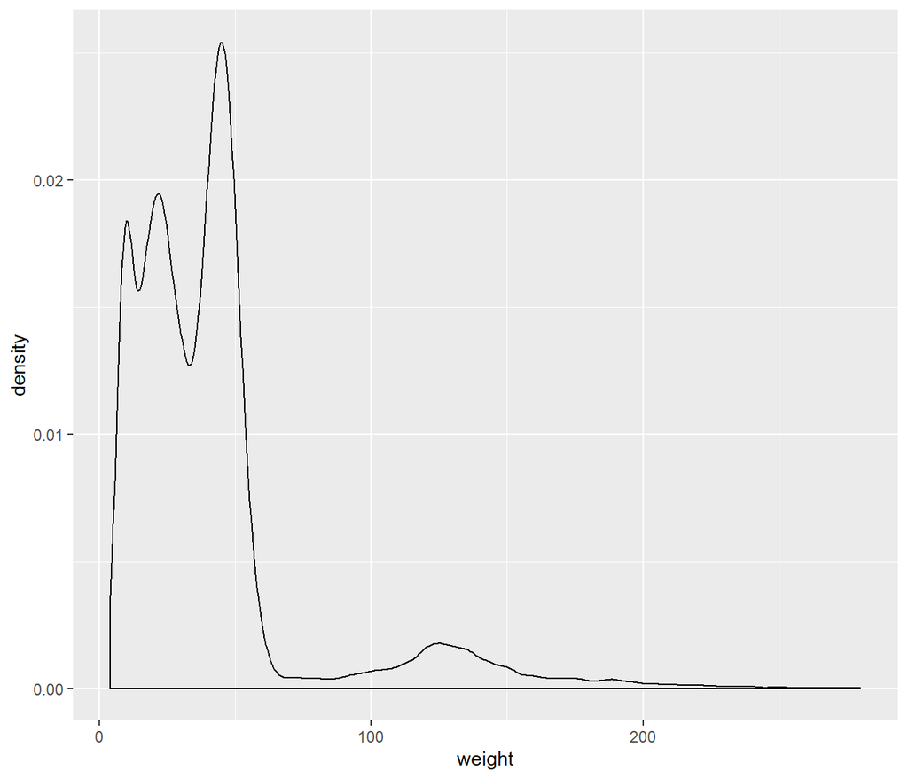

```r
surveys %>%
  ggplot(mapping = aes(x = weight)) +
  geom_density()
```

The default is an empty density plot, which is largely unsatisfying. By adding a `fill = <COLOR>` argument to `geom_density()` we can produce a nicer looking plot:

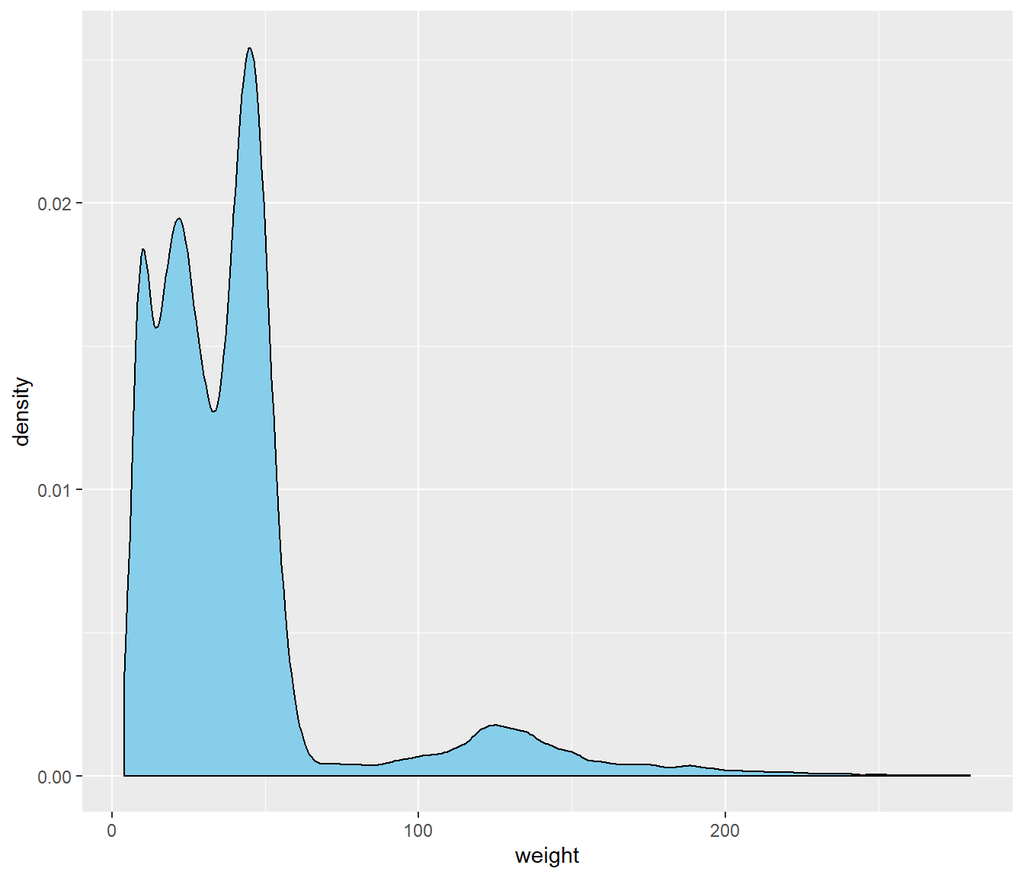

```r
surveys %>%
  ggplot(mapping = aes(x = weight)) +
  geom_density(fill = "sky blue")
```

Another frequently used plot for a single quantitative variable is the histogram. The same plot as above can be recreated using `geom_histogram()` instead of `geom_density()`. However, when you use `geom_histogram()` it gives you a warning.

> What warning do you get and why? Do you get an error like this when you use `hist()` in base `R`?

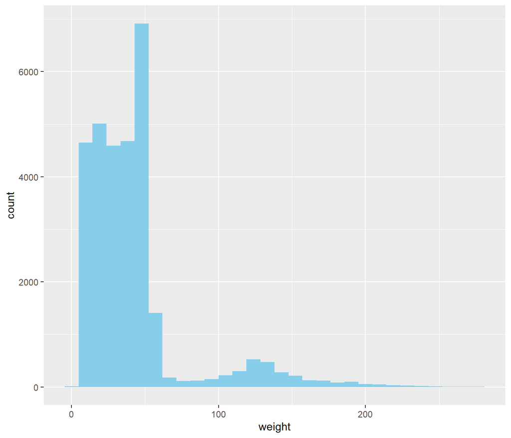

```r
surveys %>%
  ggplot(mapping = aes(x = weight)) +
  geom_histogram(fill = "sky blue")
```

I was once told that the idea behind a good histogram was to make the plot look as smooth as possible – think trying to resemble the continuous shape of the density plot.

### Challenge 4

> Use the `bins` argument to play around with the number of bins in your histogram. Compare your chosen number of bins with your neighbors!

## Bar Charts

At first glimpse, you would think that a bar plot would be simple to create, but bar plots reveal a subtle nuance of the plots we have created thus far. The following bar chart displays the total number of rodents in the `surveys` dataset, grouped by their species ID.

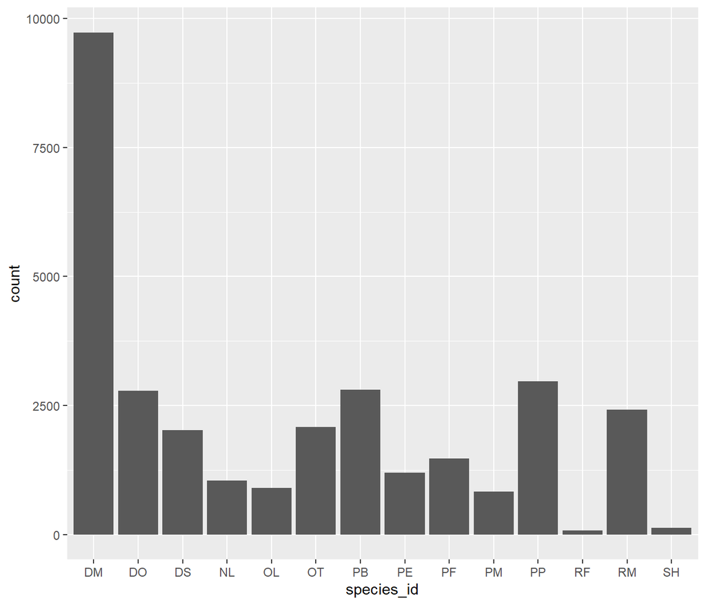

```r
surveys %>%
  ggplot(mapping = aes(x = species_id)) +
  geom_bar()
```

The x-axis displays the levels of `species_id`, a variable in the `surveys` dataset. On the y-axis `count` is displayed, but `count` is **not** a variable in our dataset! Where did `count` come from? Graphs, such as the scatterplots, display the raw values of your data. Other graphs, like bar charts and boxplots, calculate new values (from your data) to plot.

- Bar charts and histograms bin your data and then plot the number of observations that fall in each bin.
- Boxplots find summaries of your data (min, max, quantiles, median) and plot those summaries in a tidy box, with “outliers” (data over 1.5*IQR from min/max) plotted as points.
- Smoothers (as used in `geom_smooth`) fit a model to your data (you can specify, but we used the `gam` default) and then plot the predictions from that model (with associated confidence intervals).

To calculate each of these summaries of the data, `R` uses a different statistical transformation, or *stat* for short. With a bar chart this looks like the following process:

1. `geom_bar` first looks at the entire data frame
2. `geom_bar` then transforms the data using the `count` statistic
3. the `count` statistic returns a data frame with the number of observations (rows) associated with each level of `species_id`
4. `geom_bar` uses this summary data frame, to build the plot – levels of `species_id` are plotted on the x-axis and `count` is plotted on the y-axis

Generally, you can use geoms and stats interchangeably. This is because every geom has a default stat and visa versa. For example, the following code produces the same output as above:

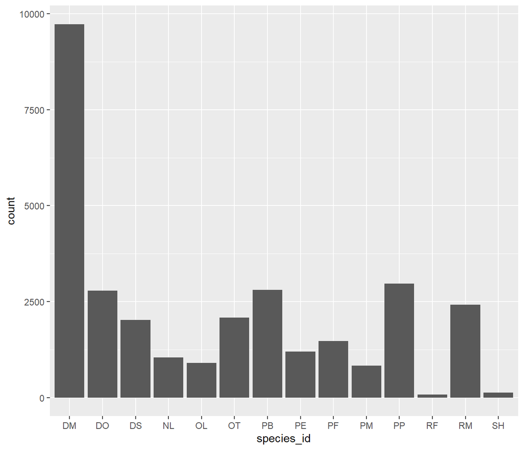

```r
surveys %>%
  ggplot(mapping = aes(x = species_id)) +
  stat_count()
```

If you so wish you could override the default stat for that geom. For example, if you wanted to plot a bar chart of proportions you would use the following code to override the `count` stat:

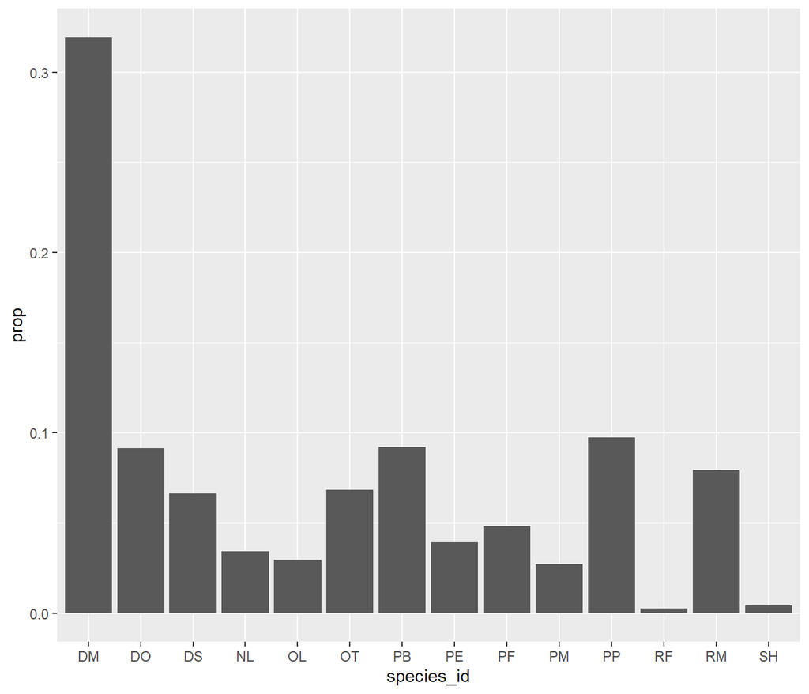

```r
surveys %>%
  ggplot(mapping = aes(x = species_id)) +
  geom_bar(aes(y = ..prop.., group = 1))
```

### Challenge 5

> Why do we need to set `group = 1` in the above proportion bar chart? In other words, what is wrong with the plot below?

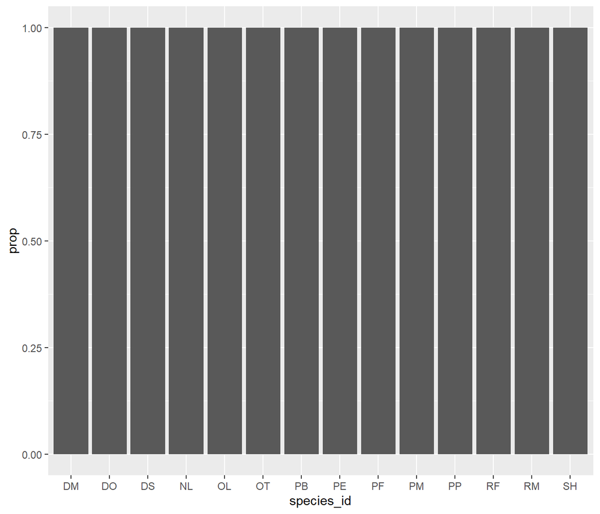

```r
surveys %>%
  ggplot(mapping = aes(x = species_id)) +
  geom_bar(aes(y = ..prop..))
```

## Colored and/or Stacked Bar Charts

Another piece of visual appeal to creating a bar chart is the ability to use colors to differentiate the different groups, or to plot two different variables in one bar chart (stacked bar chart). Let’s start with adding color to our bar chart.

As we saw before, to add a color aesthetic to the plot we need to map it to a variable. However, if we use the `color` option that we used before we get a slightly unsatisfying result.

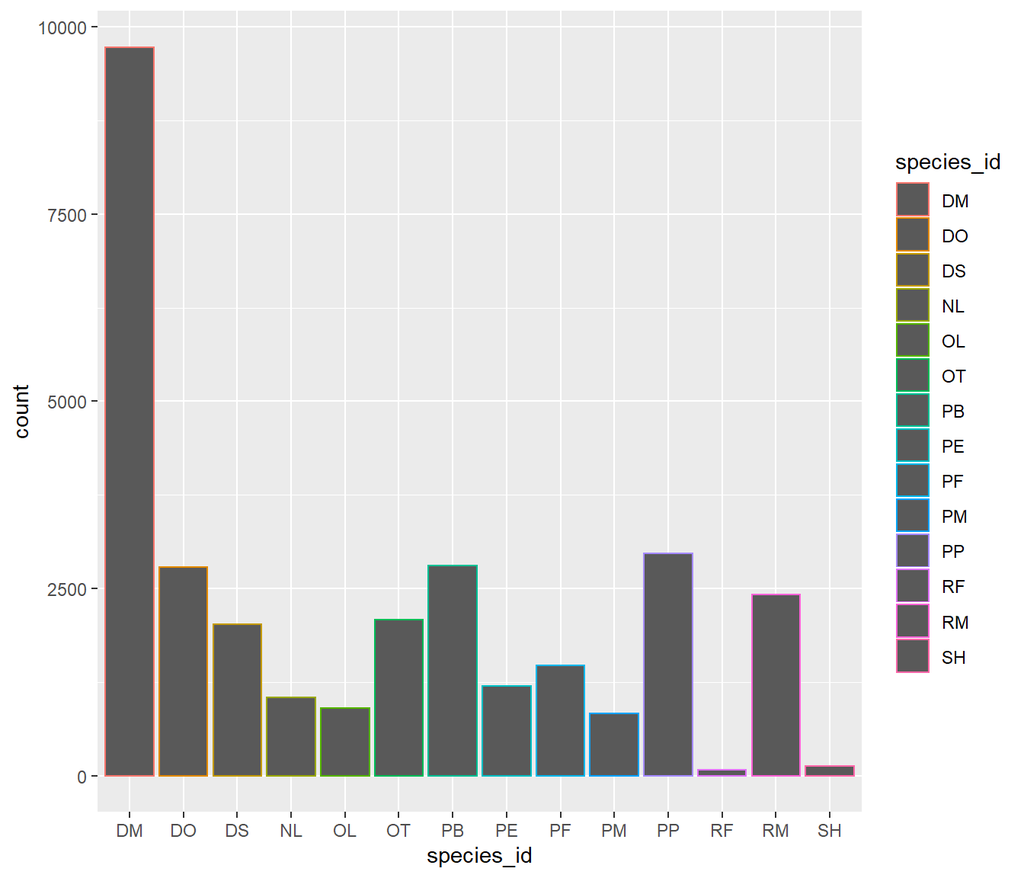

```r
surveys %>%
  ggplot(mapping = aes(x = species_id, color = species_id)) +
  geom_bar()
```

We notice that the color only appears in the outline of the bars. For a bar chart, the aesthetic that we are interested in is the `fill` of the bars.

### Challenge 6

> Change the above code so that each bar is filled with a different color.

Now suppose you are interested in whether the number of rodents in each species captured differs by sex. This would require for you to create a bar plot with two categorical variables. You have two options:

1. each of the bars for sex could be stacked within a species *OR*
2. the bars for sex could be side-by-side within a species

Let’s see how the two approaches differ. To stack bars of a second categorical variable we would instead use this second categorical variable as the `fill` of the bars. Run these two lines of code and see how they differ.

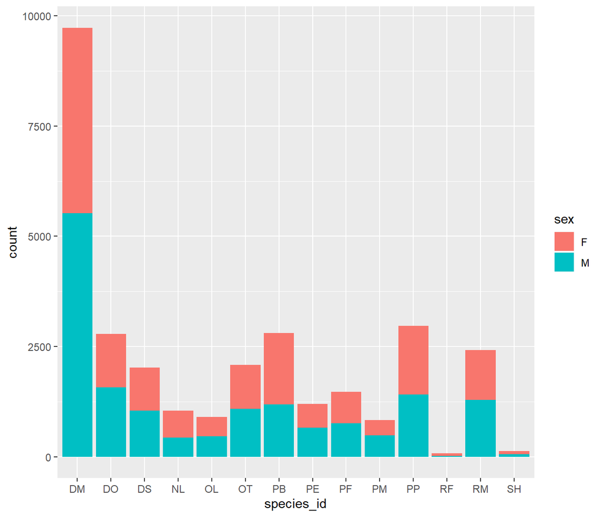

```r
surveys %>%
  ggplot(mapping = aes(x = species_id, fill = sex)) +
  geom_bar()
```

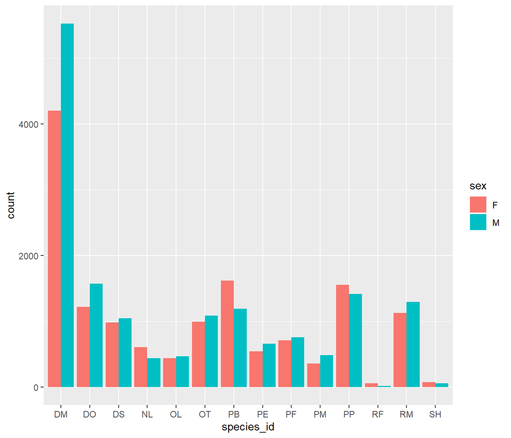

```r
surveys %>%
  ggplot(mapping = aes(x = species_id, fill = sex)) +
  geom_bar(position = "dodge")
```

In the first plot, the position was chosen automatically, but in the second plot the `position` argument was made explicit. What changes did this make in the plots?

# Plotting Time-series Data

Let’s calculate number of counts per year for each genus.

*What you will see in Data Wrangling:* First we need to group the data and count records within each group!

```r
yearly_counts <- surveys %>%
  count(year, genus)
 ## counts the number of observations (rows) for each year, genus combination
```

Time series data can be visualized as a line plot with years on the x-axis and counts on the y-axis:

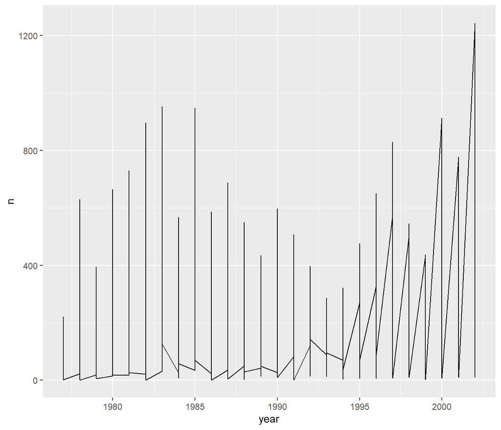

```r
yearly_counts %>%
  ggplot(mapping = aes(x = year, y = n)) +
     geom_line()
```

Unfortunately, this does not work because we plotted data for all the genera together. We need to tell `ggplot()` to draw a line for each genus by modifying the aesthetic function to include `group = genus`:

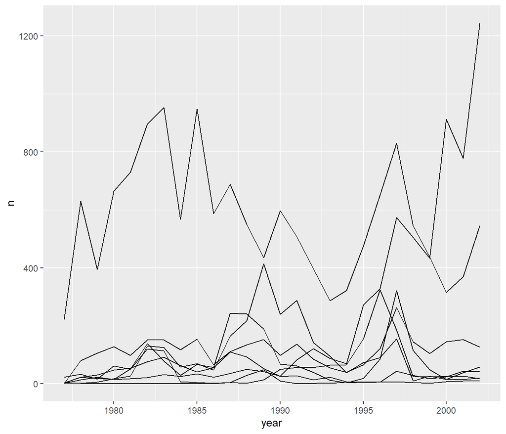

```r
yearly_counts %>%
  ggplot(mapping = aes(x = year, y = n, group = genus)) +
    geom_line()
```

Unfortunately, we can’t tell what line corresponds to which genus. We will be able to distinguish genera in the plot if we add colors (using `color` also automatically groups the data):

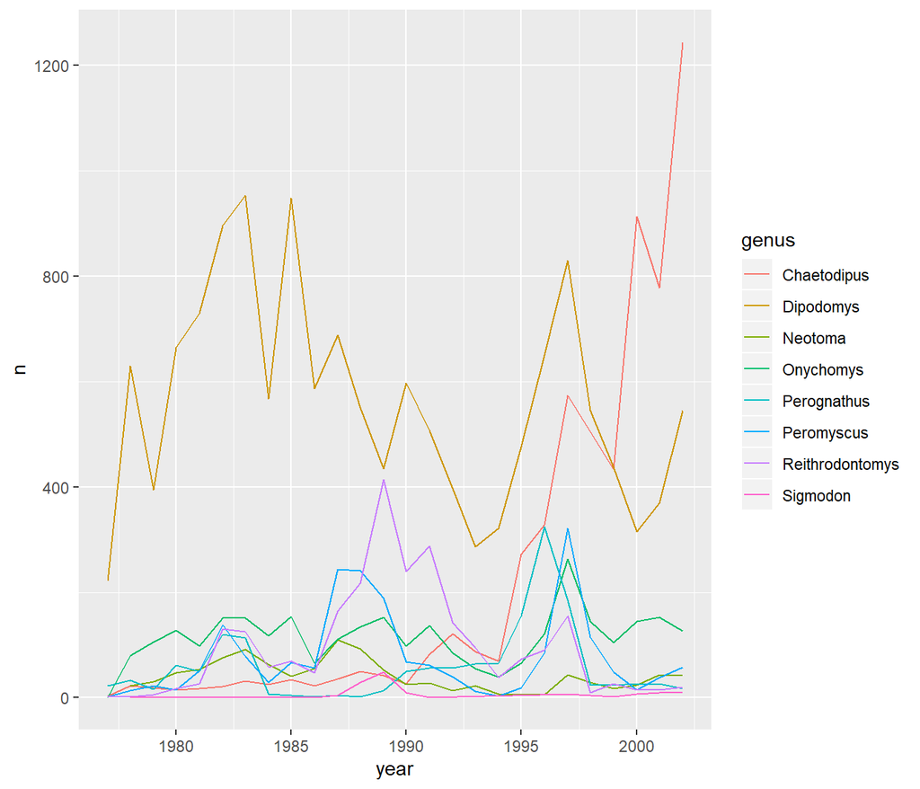

```r
yearly_counts %>%
ggplot(mapping = aes(x = year, y = n, color = genus)) +
    geom_line()
```

**Note:** When specifying the color for a line graph, you can use either the `color = <VARIABLE>` argument or the `group = <VARIABLE>` argument. Both do the same grouping of observations!

## Faceting

**`ggplot2`** has a special technique called *faceting* that allows the user to split one plot into multiple plots based on a categorical variable included in the dataset.

There are two types of `facet` functions:

- `facet_wrap()` arranges a one-dimensional sequence of panels to allow them to cleanly fit on one page – used for one variable
- `facet_grid()` allows you to form a matrix of rows and columns of panels – used for two variables

Both geometries allow to to specify faceting variables specified within the `vars()` function. The `vars()` function looks at the categorical variable you provide it with and outputs the unique levels (values) of that variable.

This looks like: `facet_wrap(facets = vars(facet_variable))` or `facet_grid(rows = vars(row_variable), cols = vars(col_variable))`.

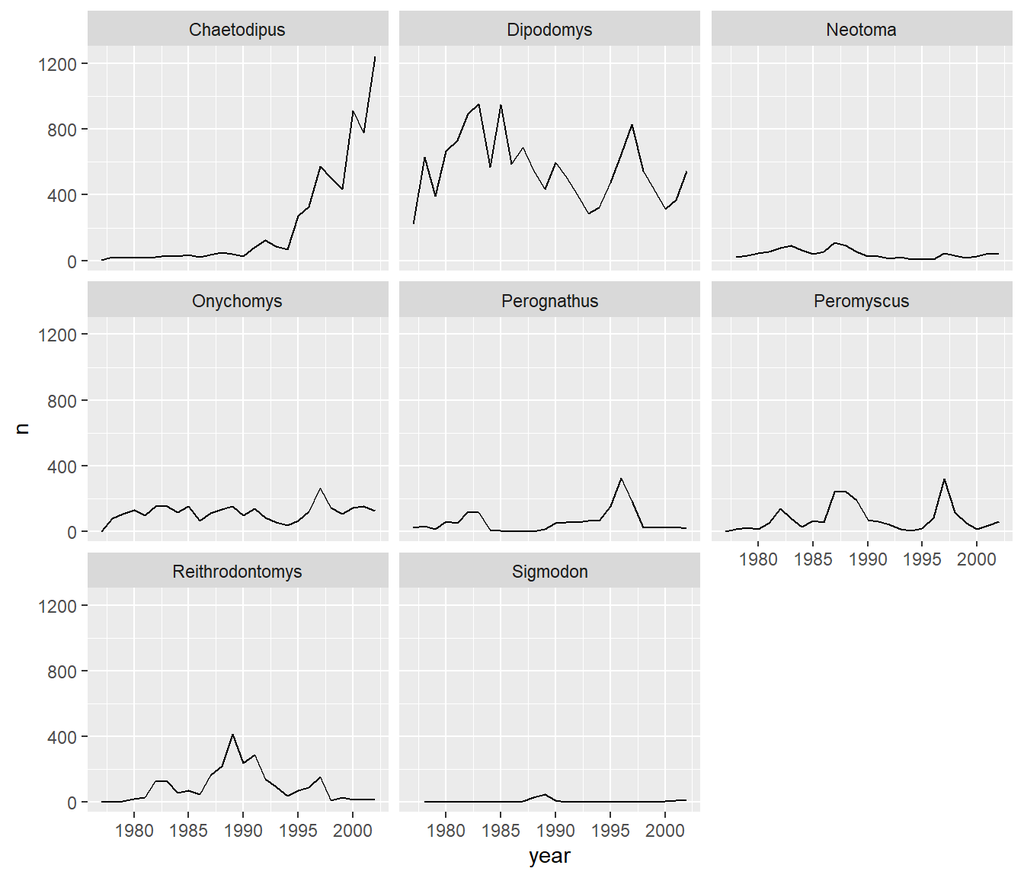

```r
yearly_counts %>%
  ggplot(mapping = aes(x = year, y = n)) +
    geom_line() +
    facet_wrap(facets = vars(genus))
```

Now we would like to split the line in each plot by the sex of the rodent captured. To do that we need to make counts in the data frame grouped by `year`, `species_id`, and `sex`:

```r
yearly_sex_counts <- surveys %>%
  count(year, species_id, sex)
## counts the number of observations (rows) for each year, species, sex combination
```

We can now make the faceted plot by splitting further by sex using `color` (within each panel):

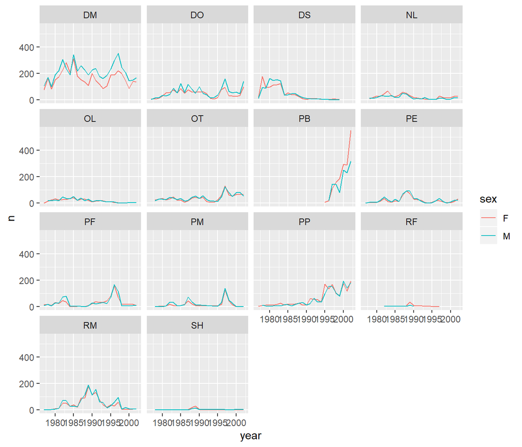

```r
yearly_sex_counts %>%
  ggplot(mapping = aes(x = year, y = n, color = sex)) +
    geom_line() +
    facet_wrap(facets =  vars(species_id))
```

You can also organize the panels only by rows (or only by columns), using the optional `nrow` and `ncol` arguments:

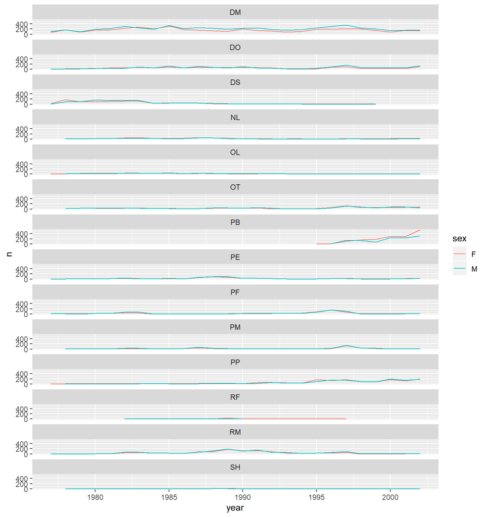

```r
yearly_sex_counts %>%
  ggplot(mapping = aes(x = year, y = n, color = sex)) +
  geom_line() +
  facet_wrap(vars(species_id), ncol = 1)
```

```r
  # One column, facet by rows
```

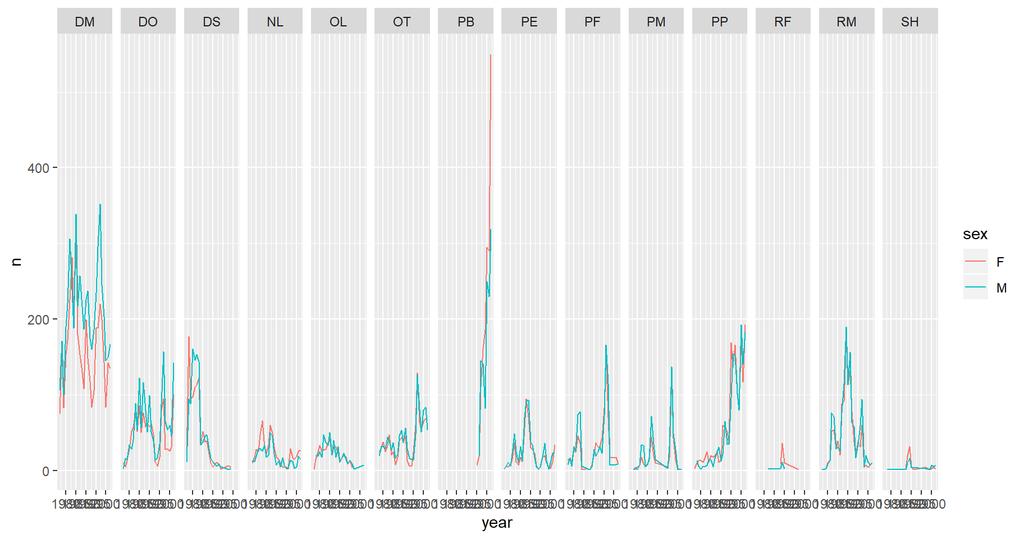

```r
yearly_sex_counts %>%
  ggplot(mapping = aes(x = year, y = n, color = sex)) +
    geom_line() +
    facet_wrap(vars(species_id), nrow = 1)
```

```r
  # One row, facet by columns
```

Now let’s use `facet_grid()` to control how panels are organised by both rows and columns:

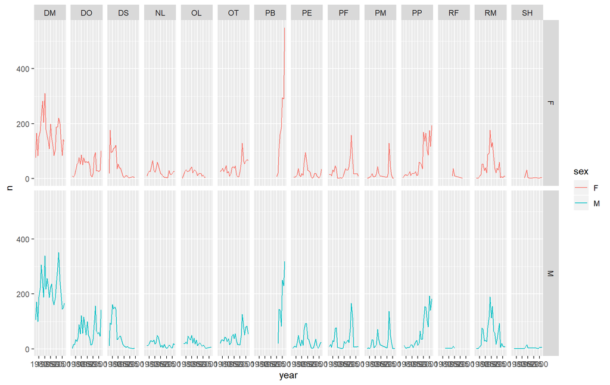

```r
yearly_sex_counts %>%
  ggplot(mapping = aes(x = year, y = n, color = sex)) +
    geom_line() +
    facet_grid(rows = vars(sex), cols =  vars(species_id))
```

**Note:** In earlier versions of **`ggplot2`** you need to use an interface using formulas to specify how plots are faceted (and this is still supported in new versions). The equivalent syntax is:

```r
# facet wrap
facet_wrap(vars(genus))    # new
facet_wrap(~ genus)        # old

# grid on both rows and columns
facet_grid(rows = vars(genus), cols = vars(sex))   # new
facet_grid(genus ~ sex)                            # old

# grid on rows only
facet_grid(rows = vars(genus))   # new
facet_grid(genus ~ .)            # old

# grid on columns only
facet_grid(cols = vars(genus))   # new
facet_grid(. ~ genus)            # old
```

### Challenge 7

> Use what you just learned to create a plot that depicts how the average weight of each species changes through the years. Play around with which variable you facet by versus plot by!

```r
## To get you started:
yearly_species_weight <- surveys %>%
  group_by(year, species_id) %>%
  ## Variables to group by!
  summarize(avg_weight = mean(weight))

## Your ggplot() code for the plot goes here!
```